# Scrape Digi-Key Table Data with pandas and Selenium

- In this project we will demonstrate the use of the pandas `read_html()` method to extract table data from the Digi-Key website, which is a massive database of electronic components
- We will also use Selenium to extract a specialized piece of data which cannot be rendered by `read_html()`
- We will extract table data from the following webpage: https://www.digikey.com/en/products/filter/accessories/159
- Scrolling down, we can see that the table appears as below:

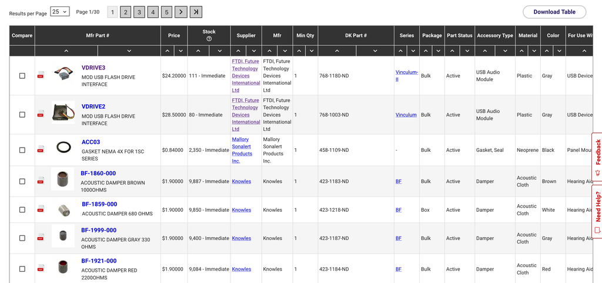

## Import required libraries

```python
import time
import pandas as pd
from selenium import webdriver
from selenium.webdriver.common.keys import Keys
from selenium.webdriver.chrome.options import Options
from selenium.common.exceptions import NoSuchElementException
```

## Read in all tables in the url

- The `read_html()` method will read in all tables from the website's html as a list

```python
url = 'https://www.digikey.com/en/products/filter/accessories/159'

table_dk = pd.read_html(url)

print(f'Total tables: {len(table_dk)}')
```

[output not shown]

## Initialize new pandas DataFrame to store the table data

```python
df = table_dk[0]

df = df.iloc[1:]

df.head()
```

[output not shown]

## Remove unneeded column

- We don't need the column 'Compare' since it doesn't hold any relevant data
  - The column can be removed using the `drop()` method
  - We specify `axis=1` to indicate that we want to remove a column and not a row

```python
df.drop('Compare', inplace=True, axis=1)

df.head()
```

[output not shown]

## Extract specialized link data not captured by `read_html()`

- We want to extract the link to the part data, which is also stored in the table
  - `read_html()` only extracts the text content, so we have to extract the link using another method (Selenium)
- First we need the XPath for each row element of the table, as well as the XPath for the `<a>` tag containing the link data

## Instantiate WebDriver

```python
chrome_options = Options()
chrome_options.add_argument('--headless')
chrome_options.add_argument('--window-size=1920x1080')
driver = webdriver.Chrome(executable_path='./chromedriver', options=chrome_options)
driver.get(url)

print(driver.title)
```

[output not shown]

## Determine number of rows in table

```python
time.sleep(3)

tr_xpath = '/html/body/div[2]/main/section/div/div[2]/div/div[2]/div/div[1]/table/tbody/tr'

rows = 1+len(driver.find_elements_by_xpath(tr_xpath))

print(rows)
```

[output not shown]

## Loop through table and extract link from each row

- We will use the `find_element_by_xpath` method to get the `<a>` tag
- Then we will use the Selenium `get_attribute` method to extract the data stored in the `href` attribute
- We will store our extracted links in a list and add these to the original DataFrame

```python
links = []

for i in range(1, rows):
    try:
        elem = driver.find_element_by_xpath(tr_xpath+'['+str(i)+']/td[2]/div/div[3]/div[1]/a')
        link = elem.get_attribute('href')
        links.append(link)
    except NoSuchElementException:
        pass

df['Link'] = links

df.head()
```

[output not shown]

## Close the WebDriver

```python
driver.quit()
```

## Complete scraper

```python
import time
import pandas as pd
from selenium import webdriver
from selenium.webdriver.common.keys import Keys
from selenium.webdriver.chrome.options import Options
from selenium.common.exceptions import NoSuchElementException

url = 'https://www.digikey.com/en/products/filter/accessories/159'

table_dk = pd.read_html(url)

print(f'Total tables: {len(table_dk)}')

df = table_dk[0]

df = df.iloc[1:]

df.drop('Compare', inplace=True, axis=1)

chrome_options = Options()
chrome_options.add_argument('--headless')
chrome_options.add_argument('--window-size=1920x1080')
driver = webdriver.Chrome(executable_path='./chromedriver', options=chrome_options)
driver.get(url)

print(driver.title)

time.sleep(3)

tr_xpath = '/html/body/div[2]/main/section/div/div[2]/div/div[2]/div/div[1]/table/tbody/tr'

rows = 1+len(driver.find_elements_by_xpath(tr_xpath))

print(rows)

links = []

for i in range(1, rows):
    try:
        elem = driver.find_element_by_xpath(tr_xpath+'['+str(i)+']/td[2]/div/div[3]/div[1]/a')
        link = elem.get_attribute('href')
        links.append(link)
    except NoSuchElementException:
        pass

df['Link'] = links

driver.quit()
```